# Assessing Factors that Affect mpg

PilotGtec EFTL

21 January 2015

Analyze mtcars data. The dataset has 32 observations on 11 variables, namely `mpg` (miles per gallon), `cyl`, `disp`, `hp`, `drat`, `wt`, `qsec`, `vs`, `am`, `gear`, and `carb`. Details on the variable descriptions can be found [here](https://stat.ethz.ch/R-manual/R-devel/library/datasets/html/mtcars.html). In particular, the automobile industry is interested in the following:

- “Is an automatic or manual transmission better for MPG”
- “Quantify the MPG difference between automatic and manual transmissions”

# Executive Summary

We explore the `mtcars` data and determine the effects of various factors to the `mpg` values of automobiles, particularly focusing on the type of transmission (as an initial approach). Three regression models are set up and compared (using anova).

- Model 1: Transmission type only
- Model 2: Transmission and weight
- Model 3: Stepwise algorithm

Results show that **Model 3** (`lm(formula = mpg ~ cyl + hp + wt + am, data = mtcars)`) is the most optimal. **Model 3** captures 86.588% of the the total variance (84.0088%, adjusted). From the coefficient values, a `1000-lb` increase in an autombile’s weight would result to a -2.4968 change in the `mpg`. With respect to the transmission, automatic transmission has 1.8092 less mpg than manual. For `hp`, on the other hand, an increase would result to a -0.0321 (decrease) in `mpg`. Finally, in general, more cylinders (`cyl`) would decrease the automobile’s `mpg`. Analysis of residuals is also presented in this report to validate the use of the models. The *Residuals vs Fitted* and the *Scale-Location* plots indicate decent fits for **Model 3** (fairly random patterns are observed); while the **Normal Q-Q plot** *suggests* consistency with normality.

## Exploratory Data Analysis

First we look at the different relationships of each of the pair of variables in the dataset by plotting the pairs (Figure A1, *Appendix*). We also mark those `x~y` pairs that fit (`r^2 > 0.700`) into a linear model. In the plot, we have excluded *cyl*, *vs*, *am*, *gear*, and *carb* as they are categorical variables— we plot them independently (Figure A2, *Appendix*). The plots give us an idea about the correlations of the variables (*Note: categorical variables are considered numerical*). To quantify the correlations, we implement the `cor` function with `wt` (-0.8677), `cyl` (-0.8522), `disp` (-0.8476), and `hp` (-0.7762) showing the highest correlation values.

## Question 1: “Is an automatic or manual transmission better for MPG”

From Figure A2, we see that there is a relationship between MPG and the type of transmission an automobile has: **Automatic** has lower *mpg* than **Manual** with mean values 17.1474 and 24.3923, respectively. To further **quantify the statistical significance of the difference**, we conduct a *Welch Two Sample t-test* on the categories with a $95\%$ confidence interval. This results to a `p-value` of 0.0014 suggesting that indeed **Automatic** has lower *mpg* than **Manual**. We have to note, however, that there are other variables that need to be considered as well. This is where the regression models come in.

## The Models

*Note: Categorical variables are converted from numerical to factor.*

In this section, we explore three models listed below. Here, we excluded the model (**Model 0**) involving all variables. This was decided after implementing the `anova` function comparing it against the model (**Model 3**) that resulted from a stepwise algorithm performed on **Model 0**. Even though **Model 3** is not significantly better (`Pr(>F) ~` 0.9588) than **Model 0**, it has fewer variables.

- Model 1: Transmission type only
- Model 2: Transmission and weight
- Model 3: Stepwise algorithm

### Comparing the Models

Computing an anova for the three models shows that **Model 3** is the most optimal when compared against **Model 2** and **Model 1**.

```
## Analysis of Variance Table
##
## Model 1: mpg ~ am
## Model 2: mpg ~ wt + am
## Model 3: mpg ~ cyl + hp + wt + am
##   Res.Df RSS Df Sum of Sq    F  Pr(>F)
## 1     30 721
## 2     29 278  1       443 76.2 3.3e-09 ***
## 3     26 151  3       127  7.3   0.001 **
## ---
## Signif. codes:  0 '***' 0.001 '**' 0.01 '*' 0.05 '.' 0.1 ' ' 1
```

**Model 3** captures 86.588% of the the total variance (84.0088%, adjusted). From the coefficients, we can see that a `1000-lb` increase in an autombile’s weight would result to a -2.4968 change on the `mpg`. With respect to the transmission, automatic transmission has 1.8092 less mpg than manual. In terms of `hp`, an increase would result to a -0.0321 (decrease) on `mpg`. Finally, in general, more cylinders (`cyl`) would decrease the automobile’s `mpg`.

```
##             Estimate Std. Error t value  Pr(>|t|)
## (Intercept) 33.70832    2.60489 12.9404 7.733e-13
## cyl6        -3.03134    1.40728 -2.1540 4.068e-02
## cyl8        -2.16368    2.28425 -0.9472 3.523e-01
## hp          -0.03211    0.01369 -2.3450 2.693e-02
## wt          -2.49683    0.88559 -2.8194 9.081e-03
## am1          1.80921    1.39630  1.2957 2.065e-01
```

In the Appendix section (Figure A3), we analyze and plot the residuals against the fitted and leverage values for **Model 3**. We also provide the Normal Q-Q plot and Scale-Location plots. The *Residuals vs Fitted* plot in Figure A3 shows a fairly random pattern, which indicates a decent fit for **Model 3**. The same can be said for the *Scale-Location* plot. Moreover, the Q-Q plot looks practicably linear (suggests consistency with normality), but the head and tail suggest relative skewness.

## Appendix

### Figure A1

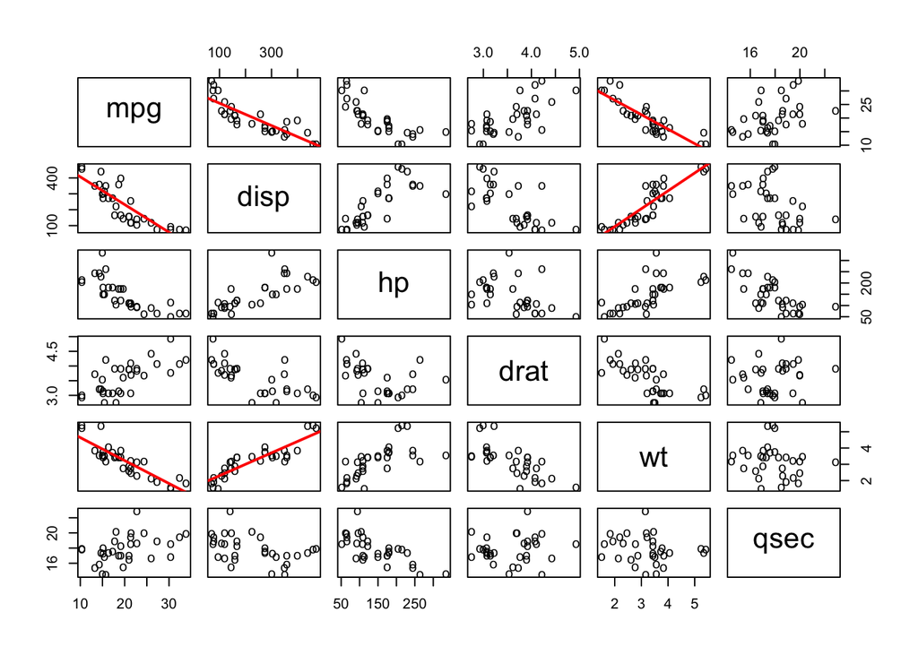

### Figure A2

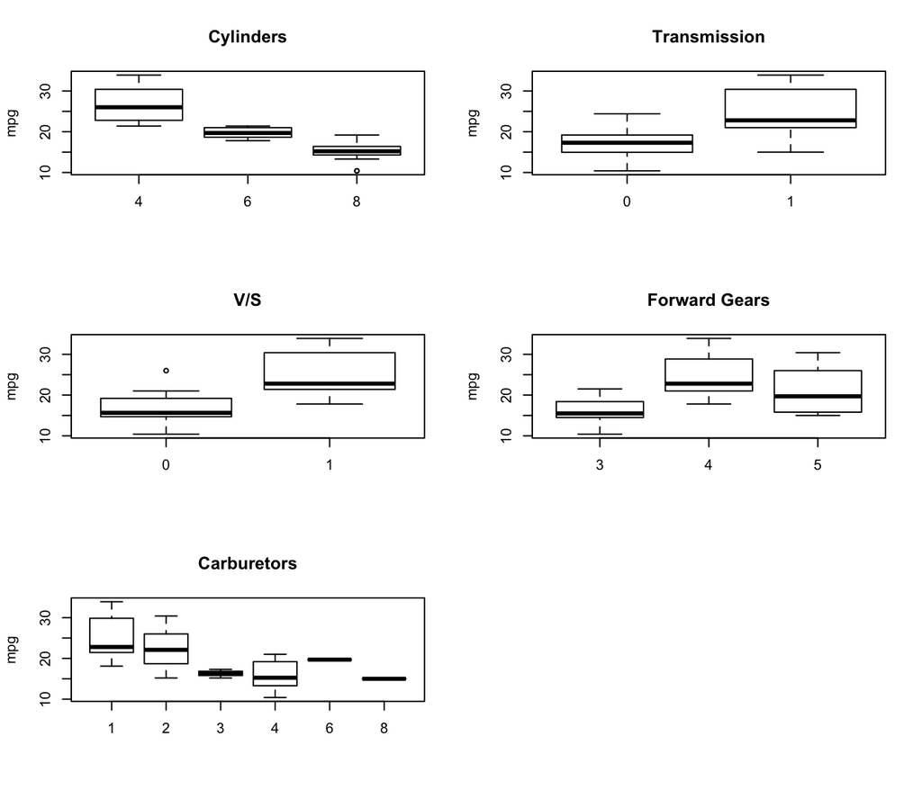

### Figure A3

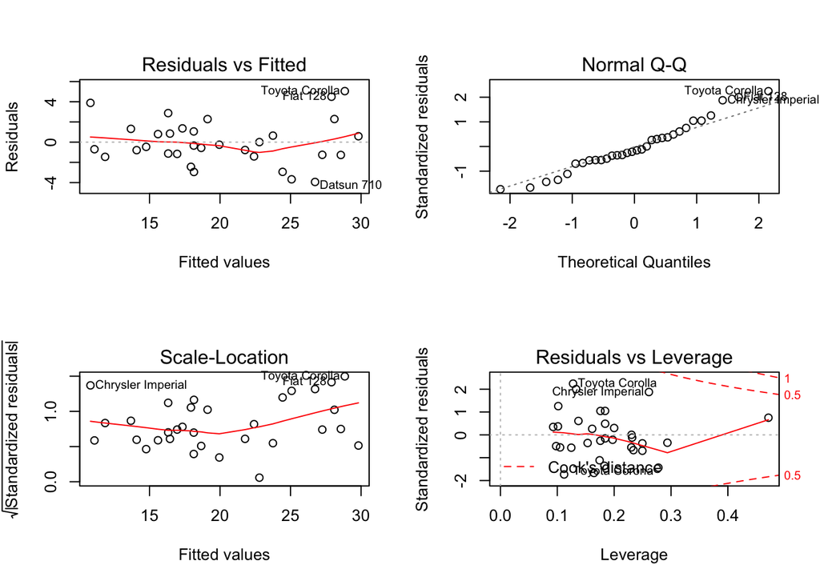